# Preliminary Analysis - Effect of Economic Crisis

Sneha Vasanth, Janani Kumar, Tigh Bradley, Gaurav Gada

February 21, 2017

Github link: https://github.com/snehavcs/Data-Science-I-Project

The financial crisis in 2007-2009 occurred as a result of risky financial dealings in the real estate market which spilled over into the world economy at large. The resulting economic downturn in the USA, particularly focusing on the economic changes before and after the collapse of Lehman Brothers in September-October 2008, provides an opportunity to compare impact of the crisis on national ecnomonies. Canada, China, India, and the USA experienced different economic changes during this period, including dramatic changes in unemployment rates.

This study explores what key economic indicators (GDP, CPI, and Unemployment rate) might have looked like in each of these countries if there had been no economic crisis in 2007-2009. Arima forecasts are utilized to project how ecnomic trends may have continued if the crisis had not occurred. The forecast models for the ‘healthy’ economic state will be compared to what actually occured in these econmies, providing a measure of the relative economic advantages and disadvantages each country experienced during this period.

Cleaning up the data!

```r
cpi = read.csv("CPI_World_Bank.csv",check.names = FALSE)
#Get country and indicator column names and remove spaces using make.names
country_indicator_names <- make.names(names(cpi[c(1:4)]))
#country_indicator_names

#Get year column names
year_column_names <- names(cpi[c(5:ncol(cpi))])
#year_column_names

#Reassign the modified column names to actual column names
names(cpi) <- c(country_indicator_names,year_column_names)
names(cpi)
```

```
##  [1] "Country.Name"   "Country.Code"   "Indicator.Name" "Indicator.Code"
##  [5] "1960"           "1961"           "1962"           "1963"
##  [9] "1964"           "1965"           "1966"           "1967"
## [13] "1968"           "1969"           "1970"           "1971"
## [17] "1972"           "1973"           "1974"           "1975"
## [21] "1976"           "1977"           "1978"           "1979"
## [25] "1980"           "1981"           "1982"           "1983"
## [29] "1984"           "1985"           "1986"           "1987"
## [33] "1988"           "1989"           "1990"           "1991"
## [37] "1992"           "1993"           "1994"           "1995"
## [41] "1996"           "1997"           "1998"           "1999"
## [45] "2000"           "2001"           "2002"           "2003"
## [49] "2004"           "2005"           "2006"           "2007"
## [53] "2008"           "2009"           "2010"           "2011"
## [57] "2012"           "2013"           "2014"           "2015"
## [61] "2016"
```

```r
#Gather all year column names into a new column called Year and assign its values to a column called CPI
clean_cpi <- gather(cpi,Year,CPI,-Country.Name,-Country.Code,-Indicator.Name,-Indicator.Code)
cpi_data <- clean_cpi[,!colnames(clean_cpi) %in% c("Indicator.Name","Indicator.Code")]
head(clean_cpi)
```

```
##   Country.Name Country.Code                    Indicator.Name
## 1        Aruba          ABW Consumer price index (2010 = 100)
## 2      Andorra          AND Consumer price index (2010 = 100)
## 3  Afghanistan          AFG Consumer price index (2010 = 100)
## 4       Angola          AGO Consumer price index (2010 = 100)
## 5      Albania          ALB Consumer price index (2010 = 100)
## 6   Arab World          ARB Consumer price index (2010 = 100)
##   Indicator.Code Year CPI
## 1    FP.CPI.TOTL 1960  NA
## 2    FP.CPI.TOTL 1960  NA
## 3    FP.CPI.TOTL 1960  NA
## 4    FP.CPI.TOTL 1960  NA
## 5    FP.CPI.TOTL 1960  NA
## 6    FP.CPI.TOTL 1960  NA
```

```r
unemp = read.csv("Unemployment_ILO.csv",check.names = FALSE)
country_indicator_names <- make.names(names(unemp[c(1:4)]))
#country_indicator_names

#Get year column names
year_column_names <- names(unemp[c(5:ncol(unemp))])
#year_column_names

#Reassign the modified column names to actual column names
names(unemp) <- c(country_indicator_names,year_column_names)
names(unemp)
```

```
##  [1] "Country.Name"   "Country.Code"   "Indicator.Name" "Indicator.Code"
##  [5] "1991"           "1992"           "1993"           "1994"
##  [9] "1995"           "1996"           "1997"           "1998"
## [13] "1999"           "2000"           "2001"           "2002"
## [17] "2003"           "2004"           "2005"           "2006"
## [21] "2007"           "2008"           "2009"           "2010"
## [25] "2011"           "2012"           "2013"           "2014"
```

```r
#Gather all year column names into a new column called Year and assign its values to a column called unemp
clean_unemp <- gather(unemp,Year,Unemployment.Rate,-Country.Name,-Country.Code,-Indicator.Name,-Indicator.Code)
unemp_data <- clean_unemp[,!colnames(clean_unemp) %in% c("Indicator.Name","Indicator.Code")]
head(clean_unemp)
```

```
##   Country.Name Country.Code
## 1        Aruba          ABW
## 2      Andorra          AND
## 3  Afghanistan          AFG
## 4       Angola          AGO
## 5      Albania          ALB
## 6   Arab World          ARB
##                                                        Indicator.Name
## 1 Unemployment, total (% of total labor force) (modeled ILO estimate)
## 2 Unemployment, total (% of total labor force) (modeled ILO estimate)
## 3 Unemployment, total (% of total labor force) (modeled ILO estimate)
## 4 Unemployment, total (% of total labor force) (modeled ILO estimate)
## 5 Unemployment, total (% of total labor force) (modeled ILO estimate)
## 6 Unemployment, total (% of total labor force) (modeled ILO estimate)
##   Indicator.Code Year Unemployment.Rate
## 1 SL.UEM.TOTL.ZS 1991                NA
## 2 SL.UEM.TOTL.ZS 1991                NA
## 3 SL.UEM.TOTL.ZS 1991           8.60000
## 4 SL.UEM.TOTL.ZS 1991           6.90000
## 5 SL.UEM.TOTL.ZS 1991          11.80000
## 6 SL.UEM.TOTL.ZS 1991          12.55804
```

```r
gdp = read.csv("gdp.csv",check.names = FALSE)
country_indicator_names <- make.names(names(gdp[c(1:4)]))
#country_indicator_names

#Get year column names
year_column_names <- names(gdp[c(5:ncol(gdp))])
#year_column_names

#Reassign the modified column names to actual column names
names(gdp) <- c(country_indicator_names,year_column_names)
names(gdp)
```

```
##  [1] "Country.Name"   "Country.Code"   "Indicator.Name" "Indicator.Code"
##  [5] "1960"           "1961"           "1962"           "1963"
##  [9] "1964"           "1965"           "1966"           "1967"
## [13] "1968"           "1969"           "1970"           "1971"
## [17] "1972"           "1973"           "1974"           "1975"
## [21] "1976"           "1977"           "1978"           "1979"
## [25] "1980"           "1981"           "1982"           "1983"
## [29] "1984"           "1985"           "1986"           "1987"
## [33] "1988"           "1989"           "1990"           "1991"
## [37] "1992"           "1993"           "1994"           "1995"
## [41] "1996"           "1997"           "1998"           "1999"
## [45] "2000"           "2001"           "2002"           "2003"
## [49] "2004"           "2005"           "2006"           "2007"
## [53] "2008"           "2009"           "2010"           "2011"
## [57] "2012"           "2013"           "2014"           "2015"
## [61] "2016"
```

```r
#Gather all year column names into a new column called Year and assign its values to a column called gdp
clean_gdp <- gather(gdp,Year,GDP,-Country.Name,-Country.Code,-Indicator.Name,-Indicator.Code)
gdp_data <- clean_gdp[,!colnames(clean_gdp) %in% c("Indicator.Name","Indicator.Code")]
head(clean_gdp)
```

```
##   Country.Name Country.Code    Indicator.Name Indicator.Code Year
## 1        Aruba          ABW GDP (current US$) NY.GDP.MKTP.CD 1960
## 2      Andorra          AND GDP (current US$) NY.GDP.MKTP.CD 1960
## 3  Afghanistan          AFG GDP (current US$) NY.GDP.MKTP.CD 1960
## 4       Angola          AGO GDP (current US$) NY.GDP.MKTP.CD 1960
## 5      Albania          ALB GDP (current US$) NY.GDP.MKTP.CD 1960
## 6   Arab World          ARB GDP (current US$) NY.GDP.MKTP.CD 1960
##         GDP
## 1        NA
## 2        NA
## 3 537777811
## 4        NA
## 5        NA
## 6        NA
```

```r
#Reading Manufacturing percentage data.
manufacturing = read.csv("Manufacturing.csv",check.names = FALSE)
country_indicator_names <- make.names(names(manufacturing[c(1:4)]))
#country_indicator_names

#Get year column names
year_column_names <- names(manufacturing[c(5:ncol(manufacturing))])
#year_column_names

#Reassign the modified column names to actual column names
names(manufacturing) <- c(country_indicator_names,year_column_names)
names(manufacturing)
```

```
##  [1] "Country.Name"   "Country.Code"   "Indicator.Name" "Indicator.Code"
##  [5] "1960"           "1961"           "1962"           "1963"
##  [9] "1964"           "1965"           "1966"           "1967"
## [13] "1968"           "1969"           "1970"           "1971"
## [17] "1972"           "1973"           "1974"           "1975"
## [21] "1976"           "1977"           "1978"           "1979"
## [25] "1980"           "1981"           "1982"           "1983"
## [29] "1984"           "1985"           "1986"           "1987"
## [33] "1988"           "1989"           "1990"           "1991"
## [37] "1992"           "1993"           "1994"           "1995"
## [41] "1996"           "1997"           "1998"           "1999"
## [45] "2000"           "2001"           "2002"           "2003"
## [49] "2004"           "2005"           "2006"           "2007"
## [53] "2008"           "2009"           "2010"           "2011"
## [57] "2012"           "2013"           "2014"           "2015"
## [61] "2016"
```

```r
#Gather all year column names into a new column called Year and assign its values to a column called gdp
clean_manufacturing <- gather(manufacturing,Year,Manufacturing.Rate,-Country.Name,-Country.Code,-Indicator.Name,-Indicator.Code)
manufacturing_data <- clean_manufacturing[,!colnames(clean_manufacturing) %in% c("Indicator.Name","Indicator.Code")]
head(clean_manufacturing)
```

```
##   Country.Name Country.Code                        Indicator.Name
## 1        Aruba          ABW Manufacturing, value added (% of GDP)
## 2      Andorra          AND Manufacturing, value added (% of GDP)
## 3  Afghanistan          AFG Manufacturing, value added (% of GDP)
## 4       Angola          AGO Manufacturing, value added (% of GDP)
## 5      Albania          ALB Manufacturing, value added (% of GDP)
## 6   Arab World          ARB Manufacturing, value added (% of GDP)
##   Indicator.Code Year Manufacturing.Rate
## 1 NV.IND.MANF.ZS 1960                 NA
## 2 NV.IND.MANF.ZS 1960                 NA
## 3 NV.IND.MANF.ZS 1960                 NA
## 4 NV.IND.MANF.ZS 1960                 NA
## 5 NV.IND.MANF.ZS 1960                 NA
## 6 NV.IND.MANF.ZS 1960                 NA
```

```r
#Reading Manufacturing percentage data.
trade = read.csv("Trade.csv",check.names = FALSE)
country_indicator_names <- make.names(names(trade[c(1:4)]))
#country_indicator_names

#Get year column names
year_column_names <- names(trade[c(5:ncol(trade))])
#year_column_names

#Reassign the modified column names to actual column names
names(trade) <- c(country_indicator_names,year_column_names)
names(trade)
```

```
##  [1] "Country.Name"   "Country.Code"   "Indicator.Name" "Indicator.Code"
##  [5] "1960"           "1961"           "1962"           "1963"
##  [9] "1964"           "1965"           "1966"           "1967"
## [13] "1968"           "1969"           "1970"           "1971"
## [17] "1972"           "1973"           "1974"           "1975"
## [21] "1976"           "1977"           "1978"           "1979"
## [25] "1980"           "1981"           "1982"           "1983"
## [29] "1984"           "1985"           "1986"           "1987"
## [33] "1988"           "1989"           "1990"           "1991"
## [37] "1992"           "1993"           "1994"           "1995"
## [41] "1996"           "1997"           "1998"           "1999"
## [45] "2000"           "2001"           "2002"           "2003"
## [49] "2004"           "2005"           "2006"           "2007"
## [53] "2008"           "2009"           "2010"           "2011"
## [57] "2012"           "2013"           "2014"           "2015"
## [61] "2016"
```

```r
#Gather all year column names into a new column called Year and assign its values to a column called gdp
clean_trade <- gather(trade,Year,Trade,-Country.Name,-Country.Code,-Indicator.Name,-Indicator.Code)
trade_data <- clean_trade[,!colnames(clean_trade) %in% c("Indicator.Name","Indicator.Code")]
head(clean_trade)
```

```
##   Country.Name Country.Code   Indicator.Name Indicator.Code Year    Trade
## 1        Aruba          ABW Trade (% of GDP) NE.TRD.GNFS.ZS 1960       NA
## 2      Andorra          AND Trade (% of GDP) NE.TRD.GNFS.ZS 1960       NA
## 3  Afghanistan          AFG Trade (% of GDP) NE.TRD.GNFS.ZS 1960 11.15703
## 4       Angola          AGO Trade (% of GDP) NE.TRD.GNFS.ZS 1960       NA
## 5      Albania          ALB Trade (% of GDP) NE.TRD.GNFS.ZS 1960       NA
## 6   Arab World          ARB Trade (% of GDP) NE.TRD.GNFS.ZS 1960       NA
```

```r
# Join all data

#gdp_cpi = merge(gdp_data,unemp_data, by=c("Country.Code","Year"), all = T) # NA's match
#manufacturing_data = merge(manufacturing_data,unemp_data,by=c("Country.Code","Year"), all = T) # NA's match
#economy_data = merge(manufacturing_data,gdp_cpi, by=c("Country.Code","Year"), all = T) # NA's match

economy_data <- left_join(gdp_data,cpi_data, by = c("Country.Code","Country.Name","Year"))%>%        left_join(.,manufacturing_data,by=c("Country.Code","Country.Name","Year")) %>%
left_join(.,unemp_data, by=c("Country.Code","Country.Name","Year")) %>%
left_join(.,trade_data,by=c("Country.Code","Country.Name","Year"))
dim(economy_data)
```

```
## [1] 15048     8
```

```r
names(economy_data)
```

```
## [1] "Country.Name"       "Country.Code"       "Year"
## [4] "GDP"                "CPI"                "Manufacturing.Rate"
## [7] "Unemployment.Rate"  "Trade"
```

```r
economy_data = economy_data[c("Country.Name", "Country.Code", "Year", "GDP", "Unemployment.Rate", "CPI","Manufacturing.Rate","Trade")]

# Clean up data
economy_data = economy_data[!(is.na(economy_data$Unemployment.Rate) & is.na(economy_data$CPI) & is.na(economy_data$GDP) & is.na(economy_data$Manufacturing.Rate) & is.na(economy_data$Trade)),]

#Backing up economy data to obtain region level data later
economy_data_full <- economy_data

country_codes = read.csv("country-codes.csv")

country_data = economy_data[economy_data$Country.Code %in% country_codes$ISO3166.1.Alpha.3,]

#rm(list = ls()[grep("economy_data", ls(), invert = T)])

economy_data <- country_data

# Clean up the working space
rm(list = ls()[grep("economy_data", ls(), invert = T)])
```

## Exploratory Analysis

How many unique observations to you have?

The number of unique observations for CPI, GDP, unemployment, manufacturing and trade respectively are:

```r
nrow(economy_data[!is.na(economy_data$CPI),])
```

```
## [1] 7167
```

```r
nrow(economy_data[!is.na(economy_data$GDP),])
```

```
## [1] 8867
```

```r
nrow(economy_data[!is.na(economy_data$Unemployment.Rate),])
```

```
## [1] 4152
```

```r
nrow(economy_data[!is.na(economy_data$Manufacturing.Rate),])
```

```
## [1] 6198
```

```r
nrow(economy_data[!is.na(economy_data$Trade),])
```

```
## [1] 8105
```

What information/features/characteristics do you have for each observation?

We modify the scope of our dataset from 1991 to 2014, since unemployment data is only available for this range.

```r
economy_data <- economy_data[economy_data$Year>=1991 & economy_data$Year<=2014,]
head(economy_data)
```

```
##              Country.Name Country.Code Year         GDP Unemployment.Rate
## 8185                Aruba          ABW 1991          NA                NA
## 8186              Andorra          AND 1991  1106928583                NA
## 8187          Afghanistan          AFG 1991          NA               8.6
## 8188               Angola          AGO 1991          NA               6.9
## 8189              Albania          ALB 1991  1139166646              11.8
## 8191 United Arab Emirates          ARE 1991 51552165622               3.0
##            CPI Manufacturing.Rate    Trade
## 8185 52.038566                 NA       NA
## 8186        NA                 NA       NA
## 8187        NA                 NA       NA
## 8188        NA               12.5 50.00000
## 8189  5.115616                 NA 34.81639
## 8191        NA                 NA       NA
```

What are the min/max/mean/median/sd values for each of these features?

```r
#Summary values for CPI
summary(economy_data$CPI,na.rm = TRUE)
```

```
##    Min. 1st Qu.  Median    Mean 3rd Qu.    Max.    NA's
##    0.00   54.99   78.50   74.79   98.32  348.20     875
```

```r
sd(economy_data$CPI, na.rm = TRUE)
```

```
## [1] 31.68783
```

```r
#Summary values for GDP
summary(economy_data$GDP,na.rm = TRUE)
```

```
##      Min.   1st Qu.    Median      Mean   3rd Qu.      Max.      NA's
## 9.365e+06 2.653e+09 1.191e+10 2.334e+11 8.283e+10 1.739e+13       177
```

```r
sd(economy_data$GDP, na.rm = TRUE)
```

```
## [1] 1.038937e+12
```

```r
#Summary values for Unemployment
summary(economy_data$Unemployment.Rate,na.rm = TRUE)
```

```
##    Min. 1st Qu.  Median    Mean 3rd Qu.    Max.    NA's
##   0.100   4.500   7.200   8.947  11.200  39.300     660
```

```r
sd(economy_data$Unemployment.Rate, na.rm = TRUE)
```

```
## [1] 6.313561
```

```r
#Summary values for Manufacturing
summary(economy_data$Manufacturing.Rate,na.rm = TRUE)
```

```
##    Min. 1st Qu.  Median    Mean 3rd Qu.    Max.    NA's
##  0.2371  7.8210 13.3600 13.7800 18.4500 47.3400     897
```

```r
sd(economy_data$Manufacturing.Rate, na.rm = TRUE)
```

```
## [1] 7.625353
```

```r
#Summary values for Trade
summary(economy_data$Trade,na.rm = TRUE)
```

```
##    Min. 1st Qu.  Median    Mean 3rd Qu.    Max.    NA's
##   0.021  54.290  78.230  87.460 105.700 531.700     490
```

```r
sd(economy_data$Trade, na.rm = TRUE)
```

```
## [1] 52.884
```

We found the averages for CPI, gdp, unemployment, manufacturing and trade for all the countries. Now, let’s manipulate the dataset to include a column to indicate if the time period for the data is before(1991-2006) or after(2007-2014) the economic crisis.

```r
economy_data <- economy_data %>% mutate(Time_Period = ifelse(Year < 2007,"Before Crisis","After Crisis"))
head(economy_data)
```

```
##           Country.Name Country.Code Year         GDP Unemployment.Rate
## 1                Aruba          ABW 1991          NA                NA
## 2              Andorra          AND 1991  1106928583                NA
## 3          Afghanistan          AFG 1991          NA               8.6
## 4               Angola          AGO 1991          NA               6.9
## 5              Albania          ALB 1991  1139166646              11.8
## 6 United Arab Emirates          ARE 1991 51552165622               3.0
##         CPI Manufacturing.Rate    Trade   Time_Period
## 1 52.038566                 NA       NA Before Crisis
## 2        NA                 NA       NA Before Crisis
## 3        NA                 NA       NA Before Crisis
## 4        NA               12.5 50.00000 Before Crisis
## 5  5.115616                 NA 34.81639 Before Crisis
## 6        NA                 NA       NA Before Crisis
```

Converting Time_Period to a factor variable and releveling the labels.

```r
economy_data$Time_Period <- as.character(economy_data$Time_Period)
economy_data$Time_Period <- factor(economy_data$Time_Period, levels = c("Before Crisis", "After Crisis"))
levels(economy_data$Time_Period)
```

```
## [1] "Before Crisis" "After Crisis"
```

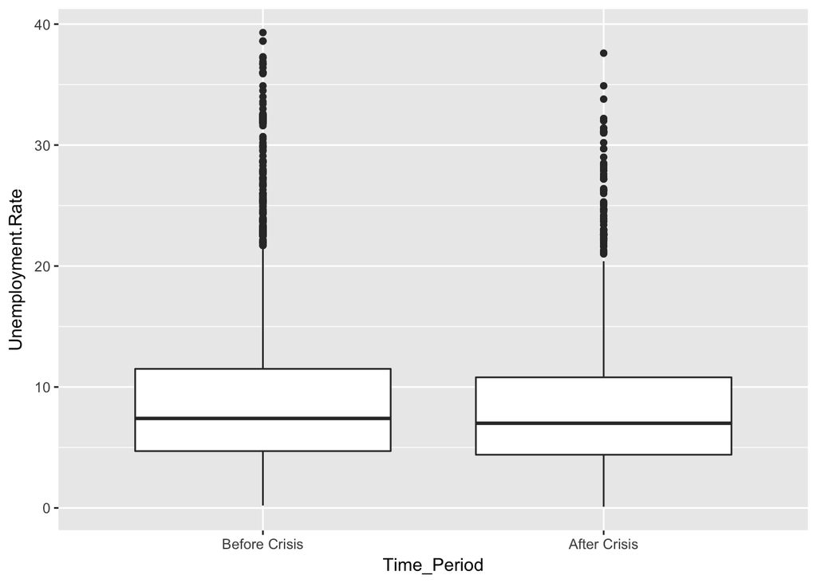

```r
ggplot(economy_data, aes(x=Time_Period, y = Unemployment.Rate))+geom_boxplot(na.rm = T)
```

The boxplot confirms the finding the median unemployment is almost the same before and after crisis. This is an interesting finding since the 2007 economic crisis led to unemployment. We will try to analyze how the unemployment trends varied post recession by drilling down further.

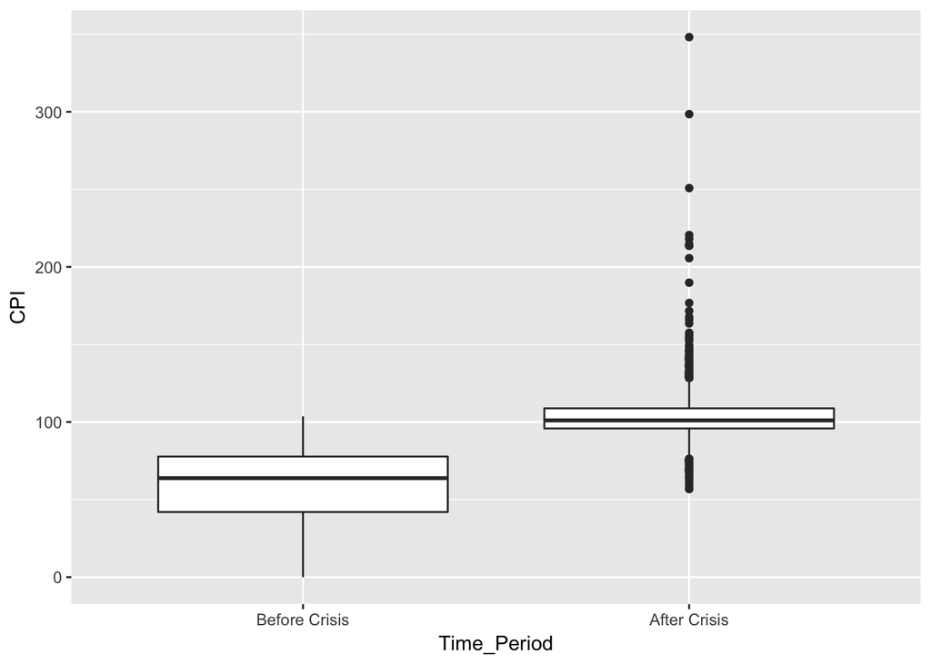

```r
ggplot(economy_data, aes(x=Time_Period, y = CPI))+geom_boxplot(na.rm = T)
```

The median CPI has increased increased post the crisis but the variability has got much less over time.

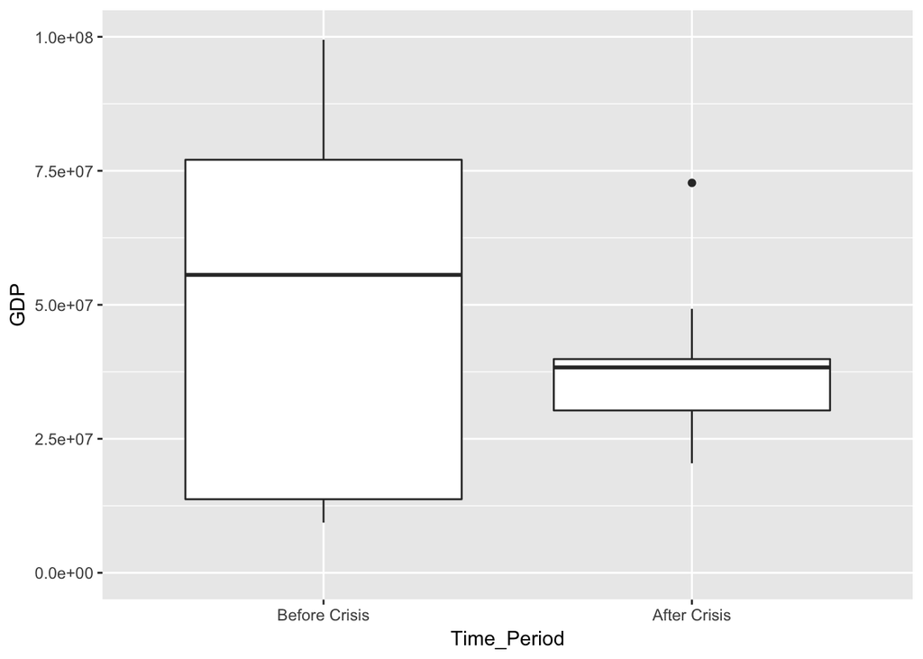

```r
ggplot(economy_data, aes(x=Time_Period, y = GDP))+ylim(0,100000000)+geom_boxplot(na.rm = T)
```

The median gdp has decreased post the crisis but the variability has got much less over time.

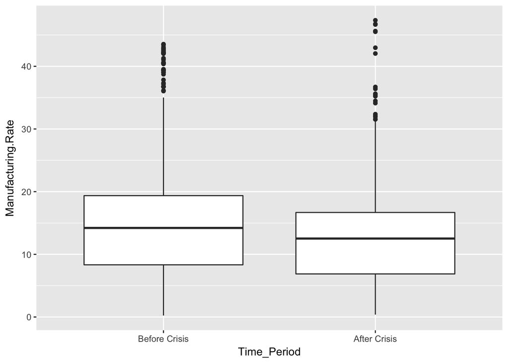

```r
ggplot(economy_data, aes(x=Time_Period, y = Manufacturing.Rate))+geom_boxplot(na.rm = T)
```

The median manufacturing rate has decreased post the crisis.

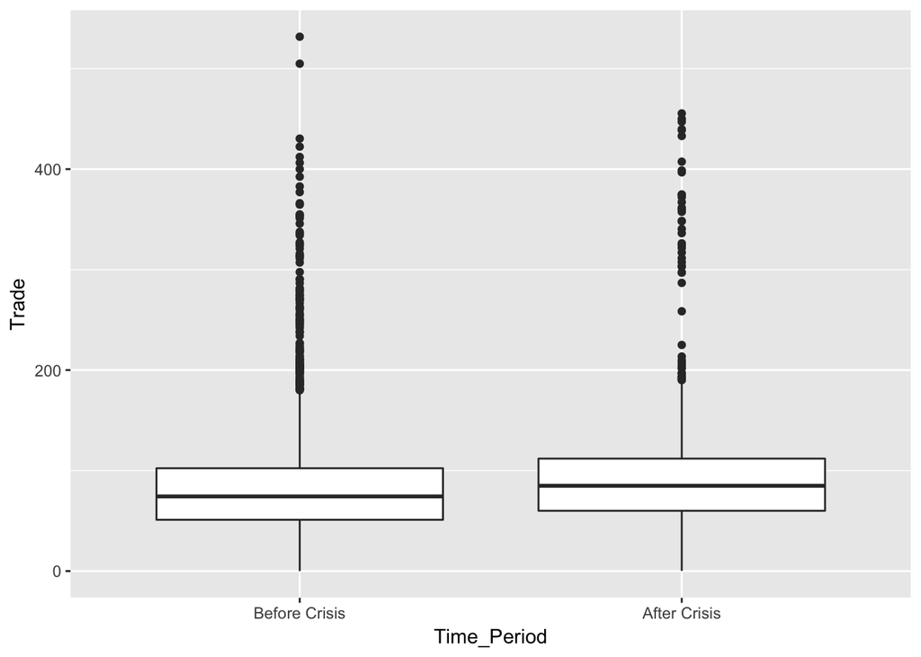

```r
ggplot(economy_data, aes(x=Time_Period, y = Trade))+geom_boxplot(na.rm = T)
```

What is the distribution of the core features (show a histogram)?

Below are the histograms of the distribution of the CPI, GDP, Unemployment, Manufacturing and Trade before and after 2007 economic crisis.

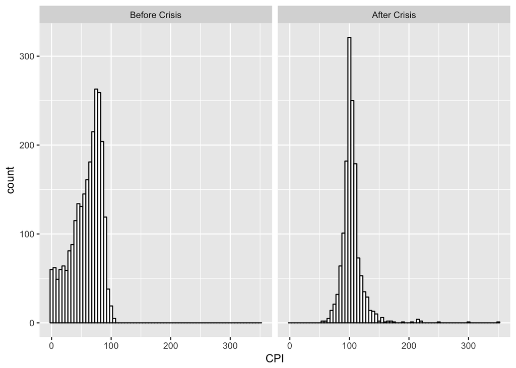

```r
ggplot(economy_data, aes(x = CPI)) +
  geom_histogram(fill = "white",
                 color = "black",
                 binwidth = 5,na.rm = T)+facet_grid(.~Time_Period)
```

The distribution of CPI was significantly different before and after crisis. The count of the number of countries with higher inflation rates increased after crisis.

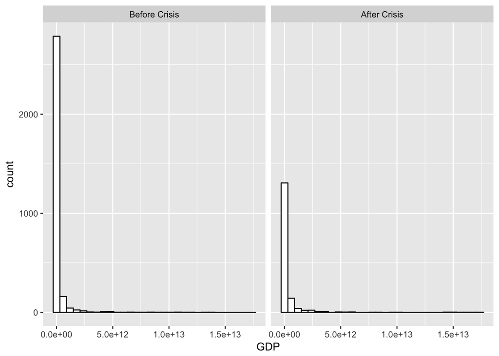

```r
ggplot(economy_data, aes(x = GDP)) +
  geom_histogram(fill = "white",
                 color = "black",na.rm = T)+facet_grid(.~Time_Period)
```

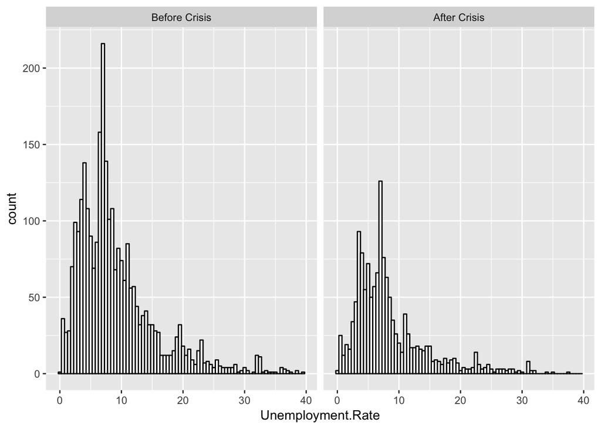

```r
ggplot(economy_data, aes(x = Unemployment.Rate)) +
  geom_histogram(fill = "white",
                 color = "black",
                 binwidth = 0.5,na.rm = T)+facet_grid(.~Time_Period)
```

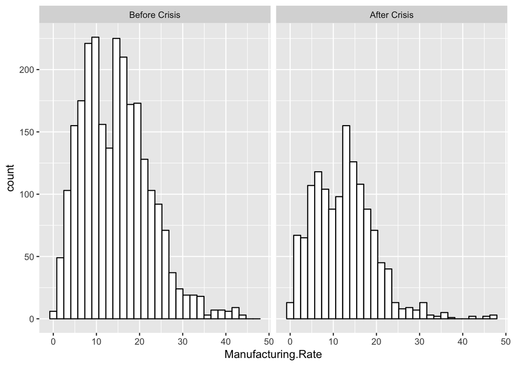

```r
ggplot(economy_data, aes(x = Manufacturing.Rate)) +
  geom_histogram(fill = "white",
                 color = "black",na.rm = T)+facet_grid(.~Time_Period)
```

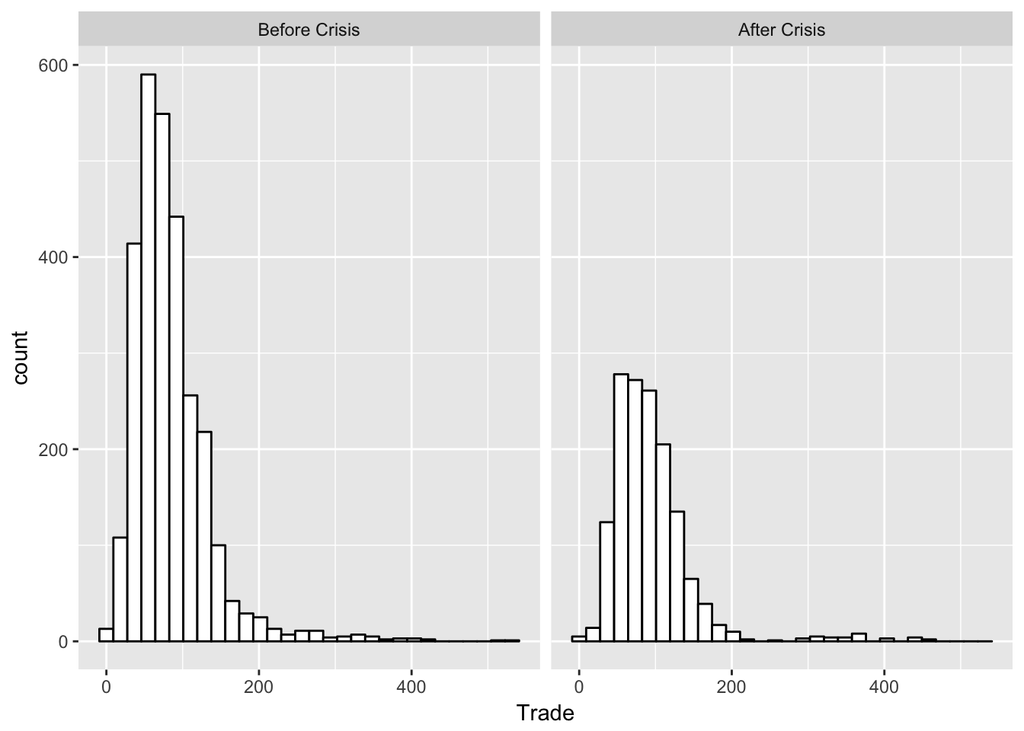

```r
ggplot(economy_data, aes(x = Trade)) +
  geom_histogram(fill = "white",
                 color = "black",na.rm = T)+facet_grid(.~Time_Period)
```

```r
region_data <- economy_data_full %>% filter(Year>=1991 & Year<=2014 & (Country.Code == 'SAS' | Country.Code == 'NAC' | Country.Code == 'EUU'))
region_data <- region_data %>% mutate(Time_Period = ifelse(Year < 2007,"Before Crisis","After Crisis"))
head(region_data)
```

```
##     Country.Name Country.Code Year         GDP Unemployment.Rate CPI
## 1 European Union          EUU 1991 7.86485e+12          8.837119  NA
## 2  North America          NAC 1991 6.78601e+12          7.250858  NA
## 3     South Asia          SAS 1991 3.66063e+11          4.498954  NA
## 4 European Union          EUU 1992 8.57021e+12          9.479230  NA
## 5  North America          NAC 1992 7.13337e+12          7.964831  NA
## 6     South Asia          SAS 1992 3.88728e+11          4.316788  NA
##   Manufacturing.Rate    Trade   Time_Period
## 1           20.99520 51.31422 Before Crisis
## 2                 NA 22.40971 Before Crisis
## 3           15.21217 20.24828 Before Crisis
## 4           20.25074 51.09461 Before Crisis
## 5                 NA 22.87170 Before Crisis
## 6           15.35937 21.88212 Before Crisis
```

```r
region_data$Time_Period <- as.character(region_data$Time_Period)
region_data$Time_Period <- factor(region_data$Time_Period, levels = c("Before Crisis", "After Crisis"))
levels(region_data$Time_Period)
```

```
## [1] "Before Crisis" "After Crisis"
```

Are there obvious trends in the data (over time, across subgroups, etc.), and are the differences statistically significant?

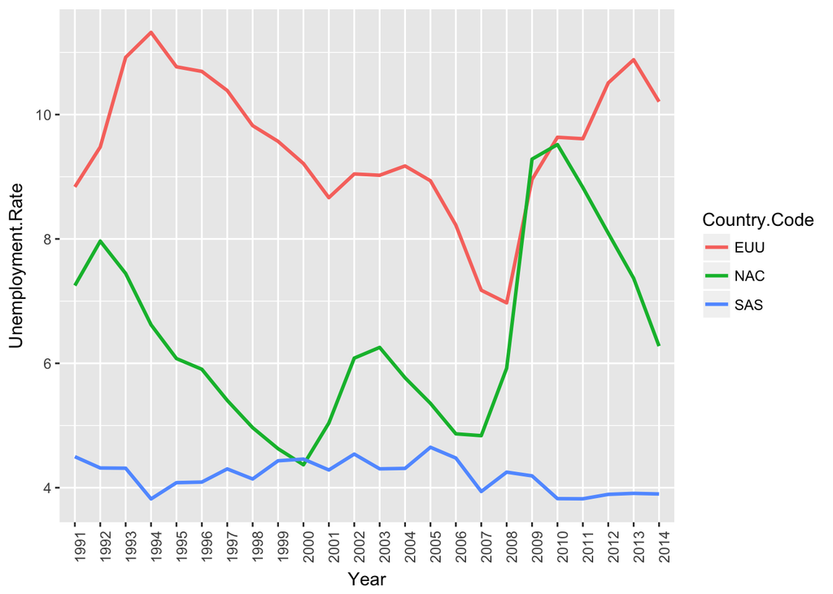

```r
unemp_compare <- region_data %>%
  select(Country.Name,Country.Code,Year,Unemployment.Rate,Time_Period) %>%
  filter(Year >= 1991 & Year<= 2014 & (Country.Code =='EUU'| Country.Code == 'SAS' | Country.Code == 'NAC')) %>%
  group_by(Year)

ggplot(unemp_compare,aes(x = Year, y = Unemployment.Rate, col = Country.Code, group = Country.Code)) +geom_line(na.rm = T,lwd = 1)+ theme(axis.text.x=element_text(angle=90, hjust=1))
```

There is a steep increase in the uemployment rates of North America and Europe while South Asia is comparitively stable post the 2008 recession.

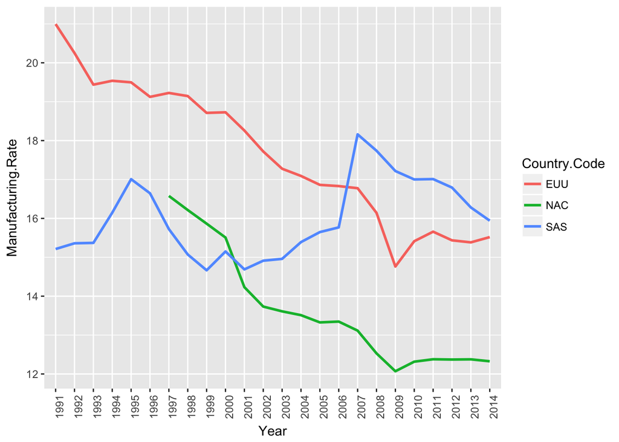

```r
manufacturing_compare <- region_data %>%
  select(Country.Name,Country.Code,Year,Manufacturing.Rate) %>%
  filter(Year >= 1991 & Year<= 2014 & (Country.Code =='EUU'| Country.Code == 'SAS' | Country.Code == 'NAC')) %>%
  group_by(Year)

ggplot(manufacturing_compare,aes(x = Year, y = Manufacturing.Rate, col = Country.Code, group = Country.Code)) +geom_line(na.rm = T,lwd = 1)+ theme(axis.text.x=element_text(angle=90, hjust=1))
```